# Il questionario

Piano Lauree Scientifiche, Laboratorio di Statistica

Aldo Solari https://aldosolari.github.io/ (DEMS)https://www.unimib.it/ateneo/dipartimenti-e-scuole/alla-scoperta-%E2%80%A6/dipartimento-economia-metodi-quantitativi-e-strategie-impresa , Laura Terzera (DISMEQ)https://www.dismeq.unimib.it/it , Paolo Maranzano, Alice Giampino, Luca Danese, Pietro Meoni, Tommaso Monti e Sara Pigazzini (Tutor)  
2020-02-10

# Scolarizzazione femminile

1. Attualmente, a livello globale, gli uomini nella fascia di età da 25 a 34 anni hanno trascorso in media circa 8 anni a scuola. Quanti anni hanno trascorso a scuola le donne nella stessa fascia di età?  
   $\Box$ A: 7 anni  
   $\Box$ B: 5 anni  
   $\Box$ C: 3 anni

[interactive chart not shown]

# Distribuzione del reddito globale

2. Quali delle seguenti curve rappresenta la distribuzione del reddito globale oggi?

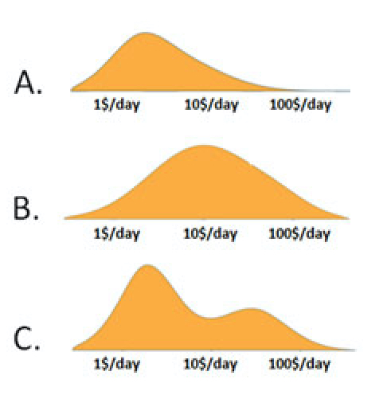

[interactive chart not shown]

# Povertà estrema

3. Negli ultimi 20 anni, la percentuale della popolazione mondiale che vive in condizioni di estrema povertà è più o meno …  
   $\Box$ A: Raddoppiata  
   $\Box$ B: Rimasta la stessa  
   $\Box$ C: Dimezzata

[interactive chart not shown]

# Durata della vita

4. Attualmente l’ aspettativa di vita alla nascita nel Regno Unito è di 81 anni. Qual è l’aspettativa di vita alla nascita nel mondo complessivamente?  
   $\Box$ A: 50 anni  
   $\Box$ B: 60 anni  
   $\Box$ C: 70 anni

[interactive chart not shown]

# Numero medio di figli per donna

5. Nel 1965, il numero di bambini nati per ogni donna nel mondo, in media, era cinque. Quanto vale oggi?  
   $\Box$ A: 2.5  
   $\Box$ B: 3.5  
   $\Box$ C: 4.5

[interactive chart not shown]

# Tasso di alfabetizzazione

6. Qual è la percentuale di adulti nel mondo di oggi che sono in grado di leggere e scrivere?  
   $\Box$ A: 80%  
   $\Box$ B: 60%  
   $\Box$ C: 40%

[interactive chart not shown]

# Catastrofi naturali

7. Come è cambiato il numero di morti all’anno dovuti a disastri naturali negli ultimi cento anni?  
   $\Box$ A: Ridotto a meno della metà  
   $\Box$ B: Più che raddoppiato  
   $\Box$ C: E’ rimasto più o meno lo stesso

[interactive chart not shown]

# Dove vivono le persone

8. Attualmente, ci sono circa 7 miliardi di persone nel mondo. Delle mappa qui sotto, quale pensi sia la rappresentazione migliore del numero di persone che vivono nelle Americhe, in Europa, in Africa e in Asia? (Ciascuna figura rappresenta 1 miliardo di persone.)

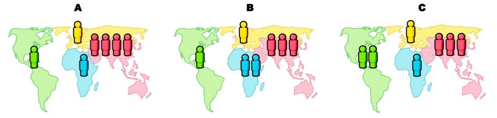

[interactive chart not shown]

# Vaccinazione dei bambini

9. Attualmente, a livello globale, qual è la percentuale di bambini con un anno di età che sono stati vaccinati contro il morbillo?  
   $\Box$ A: 20 per cento  
   $\Box$ B: 50 per cento  
   $\Box$ C: 80 per cento

[interactive chart not shown]

**Approfondimento di Pietro**

La risposta corretta alla doamanda è 80%. La risposta modale è 50%.

Ciò è dovuto a una visione pessimistica della condizione generale del mondo:si pensa che nei paesi al di fuori di quelli sviluppati la condizione sanitaria sia scarsa, quindi un’alta percentuale di vaccinati, quale l’80%, rispeccchi di più un paese ricco. Per questa ragione, si immagina che le percentuali basse di vaccinati nei paesi poveri influenzino radicalmente la percentuale mondiale.

[interactive chart not shown]

La serie storica è relativa ai dati sulla percentuale di bambini vaccinati contro il morbillo. I dati sono stati ricavati da [WorldBank](https://data.worldbank.org/indicator/SH.IMM.MEAS?locations=XM-1W-XD)

I dati sono stati ricavati dal 1990 al 2017. Come si può vedere la curva relativa alla percentuale mondiale di bambini vaccinati (curva blu) non scende mai al di sotto del 70%, in particolare dal 2005 al 2017 risulta essere sempre al di sopra dell’80%.Percentuale molto superiore rispetto a quella della fascia a basso reddito (low income, curva rossa) che comunque in questo arco temporale non scende mai al di sotto del 45%.

# Elettricità

10. Quante persone al mondo hanno accesso all’elettricità?  
    $\Box$ A: 20 %  
    $\Box$ B: 50 %  
    $\Box$ C: 80 %

[interactive chart not shown]

**Approfondimento di Samuele**

Si può notare facilmente che la maggiore parte degli intervistati ha risposto B, cioè che il 50% della popolazione mondiale ha accesso all’elettricità. La risposta corretta, come visibile nell’analisi successiva, è la C, cioè l’80%: per la precisione la percentuale di popolazione mondiale che ha accesso all’elettricità nel 2016, il dato più recente, è l’87%.

Questo risultato può essere attribuito a una visione pessimistica del fenomeno: si è spinti a immaginare che gran parte della popolazione mondiale viva in condizioni precarie, o comunque peggiori della propria. Il fenomeno viene, quindi, sottostimato ma in maniera lieve, infatti solo una piccola porzione degli intervistati ha optato per la risposta A.

[interactive chart not shown]

Fonte: [World bank](https://data.worldbank.org/indicator/EG.ELC.ACCS.ZS)

Indicatore: EG.ELC.ACCS.ZS Access to electricity is the percentage of population with access to electricity. Electrification data are collected from industry, national surveys and international sources.

I primi dati disponibili sono riferiti al 1990 e più recenti riguardano il 2016. Si può notare facilmente come la percentuale mondiale di popolazione con accesso ad elettricità ha superato la “soglia” dell’80%, cioè la risposta corretta del questionario, da più di 10 anni. Chiaramente il fenomeno assume valori notevolmente inferiori per la popolazione con un basso reddito (“Low income”): è possibile immaginare, quindi, che gli intervistati che hanno sbagliato risposta abbiano sovrastimato questa fetta di popolazione.